# Befolkningsutvecklingen i Orsa

Befolkningsutvecklingen i Orsa  
- en kort analys

Rapporten är skapad av Samhällsanalys, Region Dalarna  
Senast uppdaterad: 2026-02-27

# Sammanfattning

Syftet med den här korta analysen är att undersöka Orsas befolkningsutveckling. Ett antal viktiga slutsatser sammanfattas här:

- Efter att ha minskat såväl 2023 som 2024, ökade folkmängden i Orsa tydligt år 2025. Detta berodde i första hand på att fler flyttade till kommunen (netto)
- Det föddes färre barn i Orsa 2025, jämfört med året innan.
- En stramare nationell migrationspolitik gör att färre invandrar till Sverige än tidigare, vilket även påverkar inflyttningen till Orsa. Invandringsöverskottet har dock ökat de senaste två åren.

För mer info om statistiken, klicka på rutan nedan:

**Mer information om statistiken**

I folkmängden som SCB publicerar ingår personer som är folkbokförda i landet. För att den som flyttar till Sverige ska bli folkbokförd ska personen ha för avsikt och rätt att stanna i Sverige i minst ett år. För personer som inte är medborgare i ett EU-land innebär det att det krävs ett uppehållstillstånd som gäller minst 12 månader för att bli folkbokförd. Till följd av Rysslands invasion av Ukraina den 24 februari 2022 har Europeiska unionen (EU) beslutat att aktivera massflyktsdirektivet, vilket innebär att personer från Ukraina utan individuell prövning ska erbjudas tidsbegränsat uppehålls- och arbetstillstånd inom EU. Personer som får uppehållstillstånd enligt massflyktsdirektivet ska i regel inte bli folkbokförda och ingå i den officiella befolkningsstatistiken. Läs mer här. Sedan juni 2024 har dock personer födda i Ukraina haft möjlighet att ansöka om att bli folkbokförda i Sverige (SCB).

Under 2023 inledde Skatteverket ett arbete med att granska registret över folkbokförda. Det förde med sig att SCB avregistrerade flera tusen folkbokförda personer som visade sig inte längre bo i Sverige. I folkbokföringen har dessa registrerats som utvandrade till okänt utvandringsland. Detta arbete fortsatte under 2024. Läs mer [här](https://www.scb.se/pressmeddelande/sverige-gar-mot-lagsta-befolkningsokningen-pa-manga-ar/).

All data som används i rapporten är offentlig och finns under kategorin befolkning i SCB:s [Statistikdatabas](https://www.statistikdatabasen.scb.se/pxweb/sv/ssd/). Där finns även data för exempelvis befolkningsutvecklingen under 2025 på månadsbasis som publiceras löpande, något som inte behandlas i denna rapport.

Om redovisade statistikvärden adderas för att skapa en ny total, så adderas även osäkerheten. Det finns därför risk för att den nya totalen innehåller större osäkerhet än vad som, enligt metoden, skulle ha tillförts ett enskilt statistikvärde.

Metoden som används för röjandekontroll heter Cell Key Method (CKM). Du kan läsa mer om metoden här: [Skyddsmetoder för röjandekontroll](https://www.scb.se/dokumentation/statistiska-metoder/skyddsmetoder-for-rojandekontroll/) och här: [utveckling av röjandeskyddet](https://www.scb.se/dokumentation/statistikomraden-under-forandring/utveckling-av-rojandeskyddet/), samt i befolkningsstatistikens dokumentation (kvalitetsdeklarationen, avsnitt 2.2.6).

FAQ om CKM-metoden hittar du här: [Frågor och svar om röjandeskydd i befolkningsstatistiken](https://www.scb.se/FAQ-CKM)

# 1 Hur har befolkningen förändrats?

Till skillnad från flera andra mindre kommuner i Dalarna har befolkningen i Orsa minskat relativt lite sedan slutet på 1960-talet, från ca 7 100 invånare år 1968 till ungefär 6 900 invånare år 2025. En orsak till det kan vara den relativa närheten till Moras arbetsmarknad, vilket gör att en del av de som bor i Orsa arbetar i Mora.

Befolkningsutvecklingen tenderar att växla mellan perioder med positiv och negativ utveckling, vilket syns tydligt i diagrammet nedan. Efter ett par år med negativ befolkningsutveckling, ökade dock folkmängden i kommunen tydligt år 2025 (drygt 50 personer).

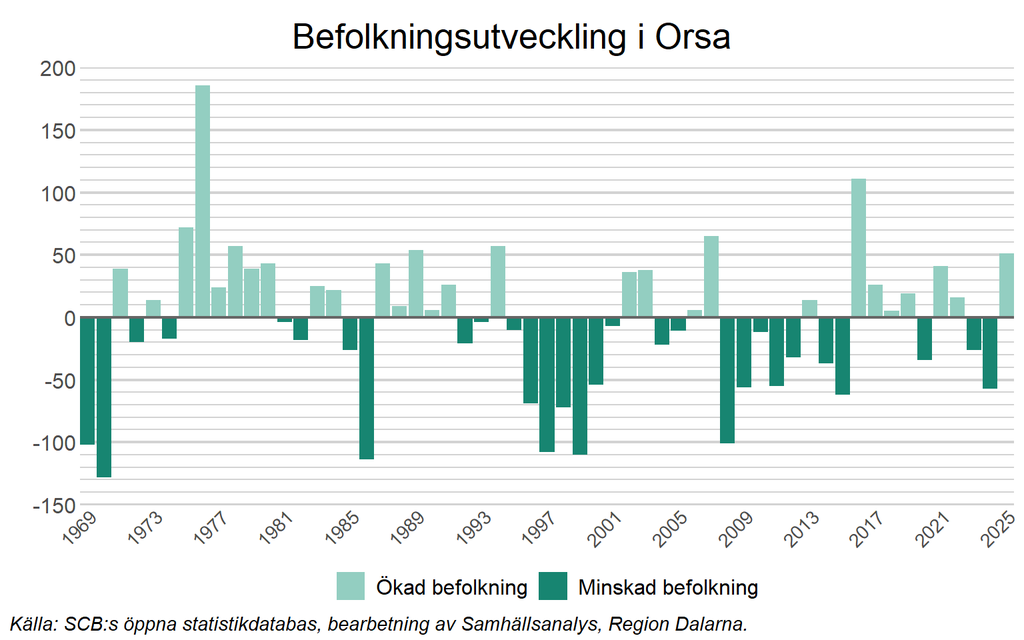

I fortsättningen av denna korta analys delas befolkningsutveckling upp i dess komponenter, födelsenetto, dvs. nettot av födda och döda, och flyttnetto, dvs. nettot av inrikes och utrikes flyttar.

# 2 Födelsenetto

En trend är att det dör färre personer i Orsa idag än det gjorde längre tillbaka i tiden. På senare år har ungefär 70-100 personer boende i kommunen dött årligen, att jämföra med ibland närmare 140 personer under 1980-talet. Detta kan i mångt och mycket förklaras av framsteg inom det medicinska området. Den förväntade livslängden har ökat över tid.

Även när det gäller antalet födslar är den långsiktiga trenden negativ. Under det sena 1980-talet och det tidigt 1990-talet föddes ofta mer än 100 barn i Orsa per år, men en tydlig negativ trend inleddes i samband med finanskrisen i början på 1990-talet. Under 2000-talet har antalet födda legat på en relativt stabil nivå, även om variationen kan vara stor från år till år. 2025 föddes knappt 50 barn, vilket dock var färre än året innan.

Med undantag för ett år i slutet av 1980-talet, har nettot mellan födda och döda, se de svarta linjerna i diagrammet nedan, varit negativt i Orsa under varje år sedan åtminstone slutet på 1960-talet. Hur många invånare som kommunen tappar på grund av det varierar relativt mycket mellan åren.

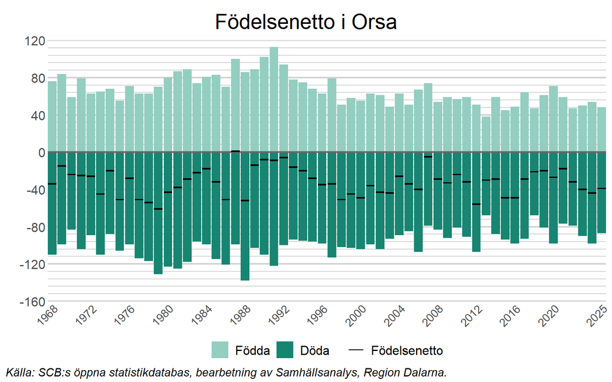

# 3 Flyttnetto

Den andra komponenten som styr befolkningsutvecklingen är det så kallade flyttnettot. Detta kan i sin tur delas upp i två komponenter, inrikes och utrikes flyttar. I det här avsnittet är fokus först på flyttnettot, innan de två komponenterna undersöks.

Nettot mellan antalet personer som flyttar till och från Orsa varierar relativt mycket mellan åren, men har på senare år varit mestadels positivt. Framförallt flyttade många till kommunen under 2016, vilket delvis kan förklaras med att många då invandrade till Orsa. Efter några år när relativt få flyttat till kommunen (netto), ökade flyttnetto tydligt år 2025.

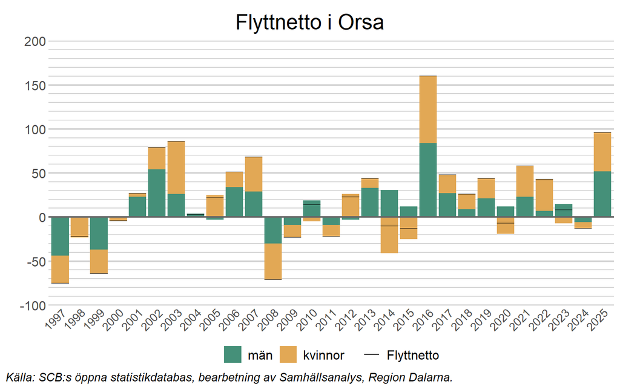

## 3.1 Utrikes flyttnetto

Som berördes i föregående avsnitt, flyttade många till Orsa under åren runt 2015-2016, vilket till viss del kan förklaras av att invandringen då var stor. I slutet av 1990-talet var invandringen låg eller till och med negativ under flera år (fler utvandrade än invandrade), men därefter skedde en gradvis ökning innan den stora toppen 2016. På senare år har invandringen minskat avsevärt, även om variationen har varit relativt stor mellan åren med omväxlande positivt och negativt netto. Efter att ha minskat 2023, var det utrikes flyttnettot återigen positivt såväl 2024 som 2025 (knappt 30 personer 2025). Detta kan potentiellt delvis förklaras med att personer födda i Ukraina sedan juni 2024 haft möjlighet att ansöka om att bli folkbokförda i Sverige (se [SCB](https://www.statistikdatabasen.scb.se/pxweb/sv/ssd/START__BE__BE0101__BE0101E/FolkmRegFlandK/table/tableViewLayout1/)). Läs mer i den klickbara rutan “mer information om statistiken” ovan. Antalet invånare från landet som är bosatta i Orsa minskade dock något mellan 2024 och 2025.

Att det utrikes flyttnettot varit lågt, eller negativt, på sistone beror dock sannolikt på en stramare nationell migrationspolitik. Notera dock att Skatteverket under 2023 påbörjade en avregistrering av utvandrade (se informationsrutan under avsnittet introduktion ovan), vilket kan få en viss påverkan på statistiken åtminstone 2023 och 2024.

Generellt invandrar ungefär lika många kvinnor och män till Orsa.

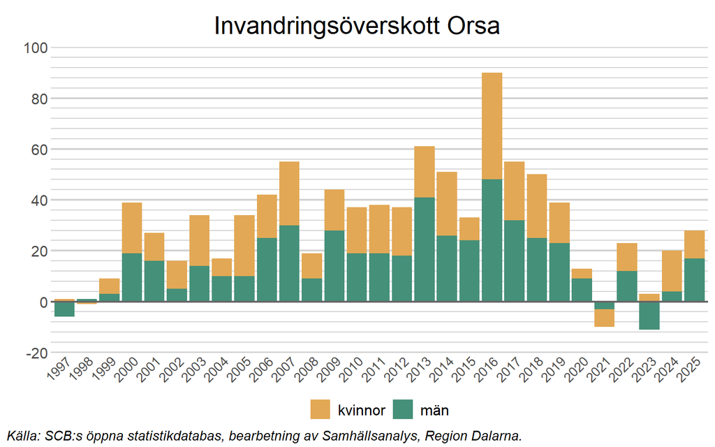

## 3.2 Inrikes flyttnetto

Det inrikes flyttnettot till Orsa varierar relativt mycket mellan åren, men har varit negativt under en majoritet av åren sedan slutet på 1990-talet. Efter ett år med negativ inrikes inflyttning (netto) 2024, var flyttnettot dock tydligt positivt igen år 2025. Detta var en viktig förklaring till att folkmängden i Orsa ökade 2025.

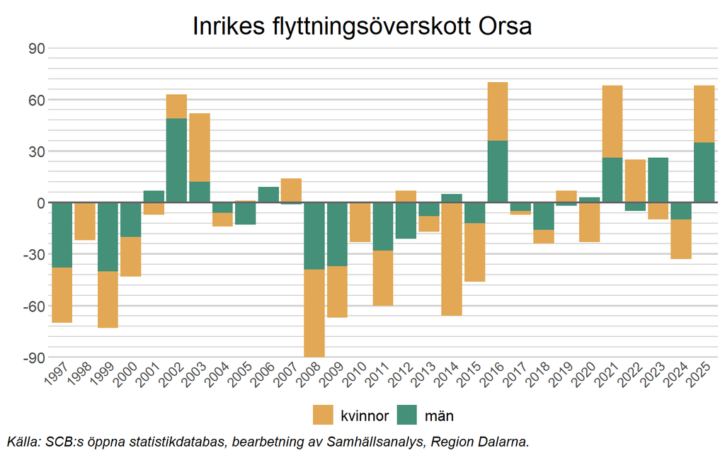

För att bättre förstå vilka som flyttar till och från kommunen inrikes, delas de som flyttar härnäst upp efter ålder. Normalt är personer mest benägna att flytta till en annan ort när de är i 20-års åldern, innan flyttandet gradvis avtar.

### 3.2.1 Uppdelat på ålder

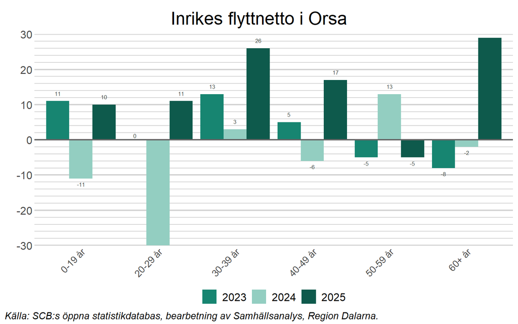

Om fokus enbart läggs på åldersgruppen 20-29 år, blir det tydligt att det i normala fall flyttar fler unga vuxna från än till kommunen inrikes. Historiskt varierar det inrikes flyttnettot i åldersgruppen mellan åren, vilket exempelvis kan bero på att olika årskullar av barn är olika stora. År 2025 flyttade 11 personer färre i åldersgruppen 20-29 år från än till kommunen inrikes.

I Dalarna som helhet flyttade fler i åldersgruppen ut än in under 2025, vilket även gäller de flesta av länets kommuner.

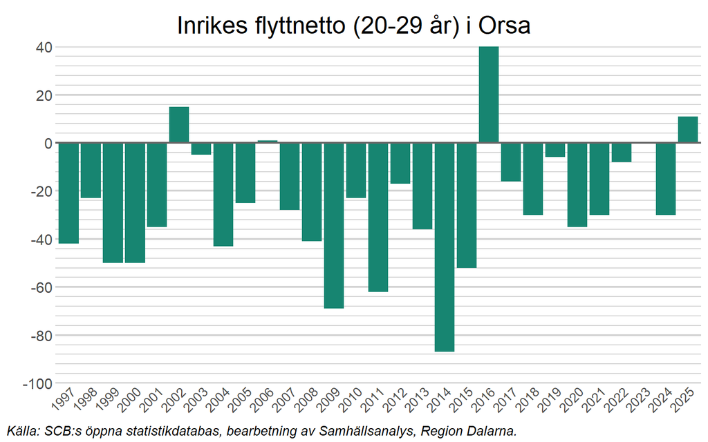

### 3.2.2 Uppdelat på bakgrund

För att ytterligare förtydliga vilka som flyttar till och från Orsa inrikes, delas de i detta avsnitt upp efter sin bakgrund, inrikes eller utrikes födda.

Tydligt är att en del av de som invandrade till Orsa runt 2015-2016 flyttade därifrån till andra delar av Sverige under åren därefter. Det inrikes flyttnettot för gruppen utrikes födda har varit negativt varje år sedan 2016. Bland de som är födda i Sverige är bilden annorlunda. Under slutet av 00-talet och början av 2010-talet flyttade många inrikes födda från Orsa till andra delar av Sverige, men den trenden vände 2016. Därefter var det inrikes flyttnettot positivt för gruppen varje år fram till 2024, när flyttnettot för inrikes födda var noll (lika många inrikes födda personer flyttade till som från Orsa under 2024).

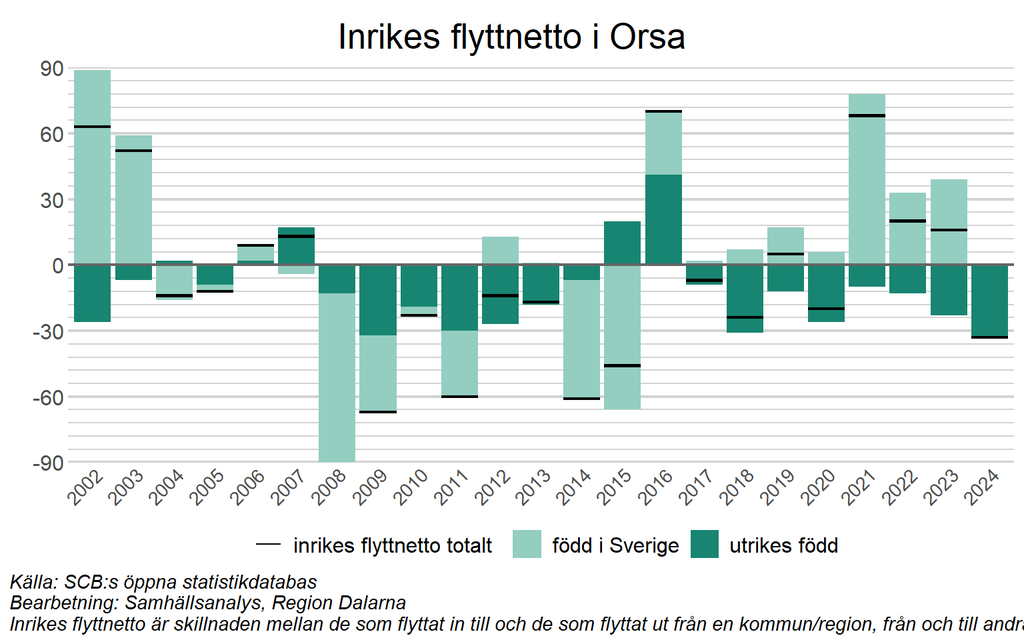

I nästa avsnitt är fokus istället på framtiden. Hur kommer Orsas folkmängd att utvecklas fram till 2034?

# 4 Vad händer i framtiden?

*Notera att prognosen nedan gjordes våren 2025. Avsnittet kommer därför att uppdateras med en ny prognos under våren 2026.*

För en djupare förståelse runt hur Region Dalarna gör befolkningsprognoser, se motsvarande avsnitt i rapporten för hela Dalarnas län. Det viktigaste att ha i åtanke är att ingen hänsyn tas i prognoserna till exempelvis företagsetableringar eller andra framtida mål och förutsättningar som kommunerna har i sina planer.

I diagrammet nedan visas befolkningsutvecklingen i Orsa fram till 2034 uppdelat på åldersgrupper, enligt Region Dalarnas prognos från våren 2025.

- Folkmängden i Orsa prognostiseras att minska till 6 720 personer år 2034, en minskning med ungefär 130 personer jämfört med 2024. I SCB:s senaste prognos (juni 2024), prognostiserades en befolkning på drygt 6 760 personer i Orsa år 2034 (se [SCB, 2024](https://www.statistikdatabasen.scb.se/pxweb/sv/ssd/START__BE__BE0401__BE0401A/BefProgRegFakN/)).
- Den största minskningen sker i den åldersgrupp som brukar benämnas arbetsför ålder, 20-65 år, som prognostiseras minska med ungefär 170 personer.
- I åldergruppen 80+ förväntas befolkning att öka med cirka 120 personer fram till 2034. Detta hänger sannolikt samman med att den förväntade livslängden fortsätter öka och att den stora gruppen “baby-boomers” börjar komma upp i 80-års åldern.
- Även i åldersgruppen 0-19 år sker en relativt stor minskning av befolkningen, knappt 140 personer.

[figure not shown]